# Breast Cancer associated SNP analysis for miRNA regulation

TargetScan v7.1 Application

Ana Jacinta-Fernandes anacjfernandes@outlook.pt

22 May 2017

## About

The following script was created to perform miRNA target predictions taking into consideration SNPs located in the 3’UTR of coding-genes. By taking advantage of the [TargetScan Human v7.1](http://www.targetscan.org/cgi-bin/targetscan/data_download.vert71.cgi) algorithm, the script locates the desired SNP in the reference sequence and creates two or more (number of alleles) files containing either one allele or the other. The analysis is performed separately and only then is compared to look for differences in the output files.

### miRNA binding

Micro RNAs (miRNAs) are small non-coding RNA molecules, about 22 nucleotides long, which are able to bind mRNA complementary sequences, either partial or full, mainly in their 3’UTR but also in their coding sequence (CDS) and 5’UTR. Importantly, miRNA are thought to confer robustness to biological mechanisms by fine-tuning transcriptional programs, mainly through post-transcriptional silencing.

**Canonical binding** of miRNAs to the mRNA can be classified as five site types, listed bellow in increasing efficacy and preferential conservation:

| Efficacy | Site Type | Description |
| --- | --- | --- |
| 5º | offset-6mer | An exact match to positions 3-8 of the mature miRNA |
| 4º | 6mer | An exact match to positions 2-7 of the mature miRNA (the seed) |
| 3º | 7mer-A1 | An exact match to positions 2-7 of the mature miRNA (the seed) followed by an ‘A’ |
| 2º | 7mer-8 | An exact match to positions 2-8 of the mature miRNA (the seed + position 8) |
| 1º | 8mer | An exact match to positions 2-8 of the mature miRNA (the seed + position 8) followed by an ‘A’ |

**Non-canonical binding** includes: extensive pairing to the 3’ of miRNA which can compensate seed mismatches**;** and centered pairing where there is contiguous, about 11-12 nucleotides long, Watson-Crick pairing in the center of the miRNA. However these are very rare as compared to canonical sites.

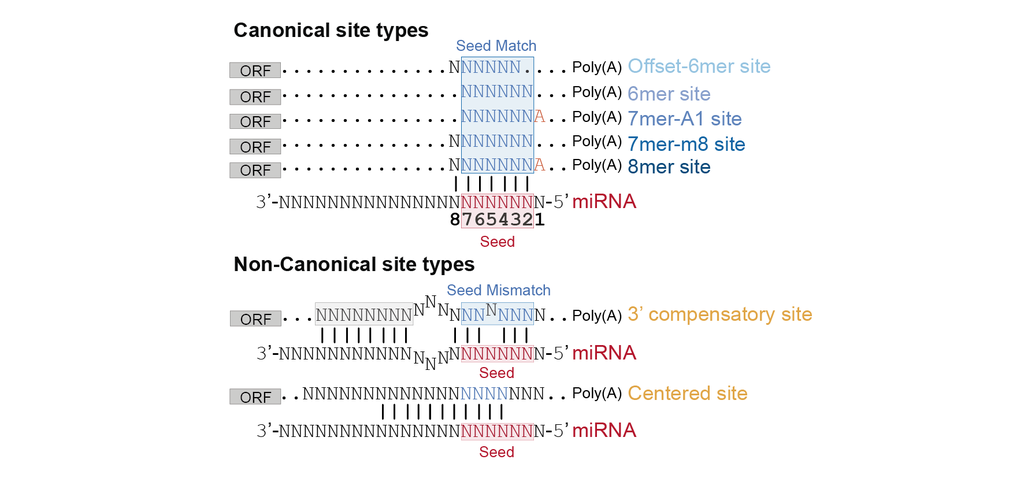

**Figure 1 |** miRNA site type classification.

### TargetScan

TargetScan ([Agarwal et al 2015](https://elifesciences.org/content/4/e05005)) is a miRNA target prediction algorithm that is available as an [html tool](http://www.targetscan.org/vert_71/) and as an [open source code](http://www.targetscan.org/cgi-bin/targetscan/data_download.vert71.cgi). It is advisable to check [TargetScan FAQ’s](http://www.targetscan.org/faqs.Release_7.html).

Here we took advantage of the provided code.

#### - Perl codes

The TargetScan algorithm is comprised of three [Perl](https://www.perl.org/) code sets that must be runned sequentially in order to calculate **context++ scores** for **canonical** miRNA binding sites.

1. **Target Prediction** (README_70.txt)
   1. `targetscan_70.pl` - Identifies conserved miRNA targets and nonconserved sites using a custom set of data;
2. **Conserved Branch Lenght and Probability of Conserved Targeting** (README_70_BL_PCT.txt)
   1. `targetscan_70_BL_bins.pl` - Uses a UTR alignment to measure relative conservation across species for that gene by calculating a mean branch length (BL), which is then used to assign the UTR to a bin (numbered 1 - 10);
   2. `targetscan_70_BL_PCT.pl` - Calculates a BL indicating the degree of conservation across species taking into account the degree of UTR conservation as indicated by the bin (calculated from targetscan_70_BL_bins.pl). If the site is for a highly conserved miRNA family, probability of conserved targeting (PCT) is also calculated;
3. **Context++ score Calculation** (README_CONTEXT_SCORES_70.txt)
   1. `targetscan_count_8mers.pl` - Performs ORF sequences analysis that matches each 3’ UTR, for ORF lengths and ORF 8mer counts;
   2. `targetscan_70_context_scores.pl` - Calculates context++ scores for a set of predicted miRNA sites in a custom set of data.

Additional information regarding each of these code steps can be found in the **README files**.

Alternatively, if you are **not** interested in calculating the scores and only want to know the targets, `targetscan_70.pl` can be runned solo. This does not require the Perl modules nor the RNAplfold application (See Dependencies.)

#### - Datasets

TargetScan also provides the following datasets in order to perform target prediction:

1. **3’UTR Sequence Dataset**
   1. `UTR_Sequences.txt` - 3’UTR sequences derived from 19,800 human protein-coding genes annotated in [Gencode version 19](https://www.gencodegenes.org/releases/19.html), and 3’-UTR multiple sequence alignments (MSAs) across 84 vertebrate species derived from the [100-way multiz alignments in the UCSC genome browser](http://hgdownload.soe.ucsc.edu/goldenPath/hg19/multiz100way/), which used the human genome release hg19 as a reference species;
2. **ORF Sequence Dataset**
   1. `ORF_Sequences.txt` - ORF sequences that matches each 3’ UTR sequence in the previous point;
3. **miRNA mature sequence and families**
   1. `miR_Family_Info.txt` - miRNA mature sequences from [miRBase](http://www.mirbase.org/ftp.shtml) (Release 21), where some miRNA sequences have alterations based on high-throughput sequencing data from [Agarwal et al 2015](https://elifesciences.org/content/4/e05005); and familial classification, based on identical seed region;
4. **Genome (hg19) coordinates of 3’ UTRs**
   1. `TSHuman_7_hg19_3UTRs.gff`
5. **Affected Isoform Ratios**
   1. `All_cell_lines.AIRs.txt` - [Affected Isoform Ratios (AIRs)](http://www.sciencedirect.com/science/article/pii/S1097276514001294) by UTR and genome region obtained from 3P-seq tags for HEK293 (epithelial cell, embryonic kidney), HeLa (epithelial cell, cervix adenocarcinoma), Huh7 (hepatocyte, liver hepatocarcinoma) and IMR90 (fibroblast, normal lung) cell lines.

#### - Context++ Score

The final Perl script of TargetScan calculates the **context++ score**. This score was developed by applying multiple linear regression models to each site type (6mer, 7mer-A1, 7mer-m8, 8mer) using **14 features** ([Agarwal et al 2015](https://elifesciences.org/content/4/e05005)) described below. The lower the context++ score, the higher the probability of targeting/repression.

| Feature | Abbreviation | Description |
| --- | --- | --- |
| **miRNA** |  |  |
| 3’UTR target-site abundance | TA_3UTR | Number of sites in all annotated 3’UTR |
| Predicted seed-pairing stability | SPS | Predicted thermodynamic stability of seed pairing |
| sRNA position 1 | sRNA1 | Identity of nucleotide at position 1 of the sRNA |
| sRNA position 8 | sRNA8 | Identity of nucleotide at position 8 of the sRNA |
| **Site** |  |  |
| Site position 8 | site8 | Identity of nucleotide at position 8 of the site |
| Local AU content | local_AU | AU content near the site |
| 3’ supplementary pairing | 3P_score | Supplementary pairing at the miRNA 3’ end |
| Predicted structural accessibility | SA | log10(Probability that a 14 nt segment centered on the match to sRNA positions 7 and 8 is unpaired) |
| Minimum distance | min_dist | log10(Minimum distance of site from stop codon or polyadenylation site) |
| Probability of conserved targeting | PCT | Probability of site conservation, controlling for dinucleotide evolution and site context |
| **mRNA** |  |  |
| ORF length | len_ORF | log10(Length of the ORF) |
| 3’UTR length | len_3UTR | log10(Length of the 3’UTR) |
| 3’-UTR offset-6mer sites | off6m | Number of offset-6mer sites in the 3’ UTR |
| ORF 8mer sites | ORF8m | Number of 8mer sites in the ORF |

## Getting Started

### Required Files

The first thing you have to do is to download the following files contained in the folder *Script_TargetScan_v7.1_SNP_analysis_in_3UTR_mRNA_Ana_Fernandes* located at [ARK](http://10.35.4.247:5000/) - lab-atmaia.

To get access to ARK please send an email to cbmrcellbits@ualg.pt with your request.

- SNP_analysis_TargetScan_v7.R
- functions.R
- targetscan_70.pl
- targetscan_70_BL_bins.pl
- targetscan_70_BL_PCT.pl
- targetscan_count_8mers.pl
- targetscan_70_context_scores.pl
- UTR_Sequences.txt
- ORF_Sequences.txt
- miR_Family_Info.txt
- TSHuman_7_hg19_3UTRs.gff
- PCT_parameters
- Agarwal_2015_parameters.txt
- All_cell_lines.AIRs.txt
- TA_SPS_by_seed_region.txt
- miRmine_v1.0
- EGAD00010000438_biological_miRNA_data

Alternatively, *Script_TargetScan_v7.1_SNP_analysis_in_3UTR_mRNA_Ana_Fernandes.zip* containing the files mentioned above can be downloaded and unzipped.

### Dependencies

In order to run the TargetScan algorithm, please **make sure** to have installed the [Statistics::Lite](http://search.cpan.org/~brianl/Statistics-Lite-3.62/Lite.pm) and [Bio::TreeIO](http://search.cpan.org/~cjfields/BioPerl-1.007001/Bio/TreeIO.pm) (Part of BioPerl) Perl modules and the [RNAplfold](http://www.tbi.univie.ac.at/RNA/documentation.html) Application from the ViennaRNA package 2. The latter will calculate average pair probabilities for locally stable secondary structures and it’s installation is optional but highly recommendable as it will affect context++ scores (site accessibility contribution will be set to 0 if not installed).

Also, you should have installed [biomaRt](https://bioconductor.org/packages/release/bioc/html/biomaRt.html), [tools](https://stat.ethz.ch/R-manual/R-devel/library/tools/html/00Index.html), [ggplot2](https://cran.r-project.org/web/packages/ggplot2/index.html), [reshape2](https://cran.r-project.org/web/packages/reshape2/index.html), [devtools](https://cran.r-project.org/web/packages/devtools/index.html) and the plotflow R packages. Depending if you are going to make a subset for miRNA expressed in breast cancer (See Chapter 1), the [miRNAmeConverter](https://bioconductor.org/packages/release/bioc/html/miRNAmeConverter.html) R package should also be installed.

## Introducing the R script

On your R integrated development environment (IDE) - for example, [R studio](https://www.rstudio.com/) -, please open the R script *SNP_analysis_TargetScan_v7.R* which contains the pipeline code to perform the desired analysis. This will be your starting point.

**STEP 1.** First, you will need to `source` *functions.R*. This is an R script which contains a custom set of functions essential for the run of *SNP_analysis_TargetScan_v7.R*. By sourcing this file, those functions will be evaluated and assigned to your Global Environment (GlobalEnv).

```r
source("./functions.R")
```

**STEP 2.** Next, the following functions will check if you have 1) installed all the necessary R packages and 2) downloaded all the necessary files. The first one will also call and activate the R packages from your library (if installed).

If your working directory is not the one where all the required files are located, then you can add their path to `check.files` (Ex: `check.files(path="insert_path_here")`). However, **it is highly recommended that you set your directory to the path where you downloaded the files**. Otherwise you might have problems running the script.

```r
check.packages()
check.files()
```

**STEP 3.** You also have the option of naming the folder where your results should be stored. If the argument is left blank, the script will automatically create a folder named ‘*Analysis*’ followed by the date you started the analysis (Ex: *Analysis_2017-05-22*). Should you prefer to name a specific folder to store your results, just enter it’s path (Ex: `file.save(path = "inset_path_here")`).This folder should already exist. Either way, you should see the variable working_path assigned to your GlobalEnv.

```r
file.save()
```

**STEP 4.** Running the full script will generate a lot of console output. Should you want to save that output just remove the hash-tag (‘#’) previous to the `sink` function and run it. All console output will be saved into the file R_console_output.txt within your working_path folder. To stop sinking, use `closeAllConnections()`.

```r
# sink(paste0(working_path,"/R_console_output.txt"), append = TRUE)
```

### 1. Subsetting your data to miRNA expressed in breast tissue

**STEP 5.** In order to reduce background noise in your analysis, miRNA that are **not** expressed in your desired cell/tissue should be removed. You can choose to do this subset by two different datasets in breast.

1. By choosing **dataset 1**, the script will use data from the [miRmine v1.0](http://guanlab.ccmb.med.umich.edu/mirmine/celltissue.php?tissue=breast&cline=) database (SRX513286) which includes RNA expression levels for normal breast (miRBase build 20). A vector called normal_breast will be assigned to your GlobalEnv containing the names of the expressed miRNA.

```r
get.miR.expression(1)
```

```
##
## Using miRmine v1.0 miRNA expression values for breast...
##
## Normal tissue expression:
##         min = 9.9 RPM    max = 29775.4 RPM
##
## Assigning 'normal_breast' to your environment...
```

2. By choosing **dataset 2**, the script will use data from [METABRIC (EGAD00010000438)](https://www.ebi.ac.uk/ega/datasets/EGAD00010000438) which includes Agilent ncRNA 60k (miRBase build 16) normalized miRNA expression data in breast cancer samples. Because the miRNA names are in a previous version of [miRBase](http://www.mirbase.org/) (Current version is 21), they will be converted to the most recent version through the `miRNAmeConverter` package. A vector called cancer_breast will be assigned to your GlobalEnv containing the names of the expressed miRNA.

```r
get.miR.expression(2)
```

```
##
## Using Agilent ncRNA 60k normalised miRNA expression values for breast cancer (miRBase build 16)...
##
## Converting miRNA names from miRBase 16 to miRBase 21...
##
## Assigning 'cancer_breast' to your environment...
```

Should you not want to use any of these datasets, you can set the argument to zero (`get.miR.expression(0)`).

Either way, miR_normalization containing your selection (1,2 or 0) will be assigned to your GlobalEnv.

### 2. Extract SNPs from SNAP output

If you are working with Genome-wide Association Studies (GWAS) -significant SNPs, the chances are that you will want to find their proxies.

[SNAP](http://archive.broadinstitute.org/mpg/snap/ldsearch.php) is an online tool that finds proxy SNPs based on linkage disequilibrium, physical distance and/or membership in selected commercial genotyping arrays.

After this, an output tab-separated file will be generated: *SNAPResults.txt*.

**STEP 6.** I have created the function `get.proxy.SNAP.data` to output a vector of all of your SNAP-generated proxies from the *SNAPResults.txt* file, including the query SNPs. This vector will later serve as input for querying the Ensembl database. The path to the SNAP output file can also be added (`get.proxy.SNAP.data(SNAP_output = "SNAPResults.txt", path = "insert_path_here")`). If left blank, the function will assume that the file will be in your working directory.

SNAP_data will also be assigned to your GlobalEnv containing the original dataframe from the *SNAPResults.txt* file.

```r
proxy_list <- get.proxy.SNAP.data(SNAP_output = "SNAPResults.txt")
```

### 3. BiomaRt query

All data regarding SNPs will be extracted from the Ensembl database trough the biomaRt R package, which enables retrieval of large amounts of data in a uniform way. The [biomaRt package](https://bioconductor.org/packages/release/bioc/html/biomaRt.html), provides an interface to a growing collection of databases implementing the BioMart software suite, such as Ensembl.

**STEP 7.** For that, first we will have to select our datasets in the selected Mart.

```r
hsapiens <- useMart("ENSEMBL_MART_ENSEMBL", dataset = "hsapiens_gene_ensembl")
snpmart <- useMart("ENSEMBL_MART_SNP", dataset = "hsapiens_snp")
```

**STEP 8.** Next `query.snp.ensembl` will query the ensembl database for the following attributes:

- **refsnp_id** - Reference SNP ID;
- **chr_name** - Chromosome number where the SNP is located;
- **allele** - Variant alleles;
- **allele_1** - Ancestral allele;
- **minor_allele** - Minor allele;
- **chrom_strand** - Chromosomal strand of the SNP annotation;
- **ensembl_gene_stable_id** - Ensembl Gene ID where the SNP is located;
- **hgnc_symbol** - HUGO Gene Nomenclature Committee (HGNC) symbol correspondent to the Ensembl Gene ID;
- **ensembl_transcript_stable_id** - Ensembl Transcript ID where the SNP is located;
- **ensembl_transcript_chrom_strand** - Chromosomal strand of the Transcript annotation;
- **consequence_type_tv** - Localization/Consequence of the SNP in the transcript.

This query will generate a dataframe called dataset in your GlobalEnv which will also be saved as a tab-separated .txt file in your working_path folder, unless a specific path is added (Ex: `query.snp.ensembl(snp = proxy_list, path = "insert_path_here")`).

You should also be aware that this function is designed to remove “LRG” gene names and chromosome annotations starting by “CHR”.

```r
dataset <- query.snp.ensembl(snp = proxy_list)
```

**EXAMPLE**

For instance, let’s take a look at the output generated by `query.snp.ensembl` for **rs6884232**. **This example will be used throughout the remaider of this document**.

```r
dataset <- query.snp.ensembl(snp = "rs6884232")
```

```
## [1] WARNING: The Ensembl SNP mart finds only 1 SNPs out of 1, as the database excludes flagged variants
##
## Processing ensembl information...
##
## [1] Removed 0 LRG (Locus Reference Genomic) gene names
## [1] Removed 0 CHR chromossome name annotations
##
## The data includes the following 1 hgnc gene symbols for 1 ensembl ID's:
##
## [1] "ATG10"
##
## The data includes the following SNP genomic localizations:
##
## [1] "3_prime_UTR_variant"           "downstream_gene_variant"
## [3] "non_coding_transcript_variant" "intron_variant"
##
## Creating .txt file with data: /home/acjfernandes/SNP_analysis_TargetScan_miRNA/R_Markdown/Analysis_2017-05-22
```

**Table 1. |** `dataset` for rs6884232.

| refsnp_id | chr_name | allele | allele_1 | minor_allele | chrom_strand | ensembl_gene_stable_id | hgnc_symbol | ensembl_transcript_stable_id | ensembl_transcript_chrom_strand | consequence_type_tv |
| --- | --- | --- | --- | --- | --- | --- | --- | --- | --- | --- |
| rs6884232 | 5 | G/A | A | G | 1 | ENSG00000152348 | ATG10 | ENST00000282185 | 1 | 3_prime_UTR_variant |
| rs6884232 | 5 | G/A | A | G | 1 | ENSG00000152348 | ATG10 | ENST00000458350 | 1 | 3_prime_UTR_variant |
| rs6884232 | 5 | G/A | A | G | 1 | ENSG00000152348 | ATG10 | ENST00000504770 | 1 | downstream_gene_variant |
| rs6884232 | 5 | G/A | A | G | 1 | ENSG00000152348 | ATG10 | ENST00000513634 | 1 | downstream_gene_variant |
| rs6884232 | 5 | G/A | A | G | 1 | ENSG00000152348 | ATG10 | ENST00000508814 | 1 | non_coding_transcript_variant |
| rs6884232 | 5 | G/A | A | G | 1 | ENSG00000152348 | ATG10 | ENST00000508814 | 1 | intron_variant |
| rs6884232 | 5 | G/A | A | G | 1 | ENSG00000152348 | ATG10 | ENST00000514253 | 1 | non_coding_transcript_variant |
| rs6884232 | 5 | G/A | A | G | 1 | ENSG00000152348 | ATG10 | ENST00000514253 | 1 | intron_variant |

**STEP 9.** Next, a subset to 3’UTR located SNPs will be done. The following script lines will generate a vector, refsnp_id, with your 3’UTR located SNPs and print in your console their gene names.

```r
BioRelevant_miRNAarm_3UTR <- dataset[grep("3_prime_UTR_variant", dataset$consequence_type_tv),]

refsnp_id <- unique(BioRelevant_miRNAarm_3UTR$refsnp_id)
refsnp_id<- as.vector(refsnp_id)
unique(BioRelevant_miRNAarm_3UTR$hgnc_symbol)
```

```
## [1] "ATG10"
```

**Table 2. |** `BioRelevant_miRNAarm_3UTR` for rs6884232.

| refsnp_id | chr_name | allele | allele_1 | minor_allele | chrom_strand | ensembl_gene_stable_id | hgnc_symbol | ensembl_transcript_stable_id | ensembl_transcript_chrom_strand | consequence_type_tv |
| --- | --- | --- | --- | --- | --- | --- | --- | --- | --- | --- |
| rs6884232 | 5 | G/A | A | G | 1 | ENSG00000152348 | ATG10 | ENST00000282185 | 1 | 3_prime_UTR_variant |
| rs6884232 | 5 | G/A | A | G | 1 | ENSG00000152348 | ATG10 | ENST00000458350 | 1 | 3_prime_UTR_variant |

### 4. BiomaRt query (hg19)

**STEP 10.** Since the TargetScan 3’UTR sequences dataset is represented in hg19 coordinates (latest version is hg38), we will have to get our SNP hg19 coordinates. This will be later on compared to the 3’UTR sequence coordinates to make sure that the SNP falls within that sequence.

```r
hg19_snp = useMart(biomart="ENSEMBL_MART_SNP", host="grch37.ensembl.org", path="/biomart/martservice", dataset="hsapiens_snp")   # Access SNP database from hg19

snp_coordinates_hg19 <- snp.coordinates.hg19(refsnp_id)
```

**Table 3. |** `snp_coordinates_hg19` for rs6884232.

| refsnp_id | chr_name | chrom_start | allele | allele_1 | minor_allele |
| --- | --- | --- | --- | --- | --- |
| rs6884232 | 5 | 81550043 | G/A | A | G |

### 5. 3’UTR sequence and coordinates query

**STEP 11.** Next we will retrieve all sequences regarding the genes where the SNPs are located. This step ensures that you will not have to load the entire *UTR_Sequences.txt* to you GlobalEnv, occupying a significant portion of your RAM. `grep.file` will execute a grep command from bash based on the hgnc symbol as a pattern.

*If the hgnc symbol is not found in the ‘UTR sequences’ file try using it’s aliases. For instance, KMT5A is not found but it’s alias SETD8 is.*

```r
hgnc_symbol <- unique(BioRelevant_miRNAarm_3UTR$hgnc_symbol)
hgnc_symbol<- na.omit(hgnc_symbol)

UTR_sequences_list <- lapply(hgnc_symbol,grep.file, filename = "UTR_Sequences.txt")
UTR_sequences<-do.call(rbind,UTR_sequences_list)
colnames(UTR_sequences)<- c("Ensembl.ID","Gene.ID","Gene.Symbol","Species.ID","UTR.sequence")
```

```
## [1] "grep -P \"\\bATG10\\b\" /home/acjfernandes/SNP_analysis_TargetScan_miRNA/R_Markdown/UTR_Sequences.txt"
```

**Table 4. |** `Head` of `UTR_sequences` for rs6884232. Fift collumn ‘UTR.sequence’ is ommited on purpose.

| Ensembl.ID | Gene.ID | Gene.Symbol | Species.ID |
| --- | --- | --- | --- |
| ENST00000282185.3 | ENSG00000152348.11 | ATG10 | 7897 |
| ENST00000282185.3 | ENSG00000152348.11 | ATG10 | 8364 |
| ENST00000282185.3 | ENSG00000152348.11 | ATG10 | 8469 |
| ENST00000282185.3 | ENSG00000152348.11 | ATG10 | 8478 |
| ENST00000282185.3 | ENSG00000152348.11 | ATG10 | 8496 |
| ENST00000282185.3 | ENSG00000152348.11 | ATG10 | 8839 |

**STEP 12.** Notice that the `Species.ID` comes from the [NCBI Taxonomy](https://www.ncbi.nlm.nih.gov/taxonomy) database. Therefore the **Tax ID for *Homo sapiens* is 9606** and a subset can be made.

```r
UTR_sequences_hsa<- UTR_sequences[grep("^9606$",UTR_sequences$Species.ID),]
```

**Table 5. |** `UTR_sequences_hsa` for rs6884232. Fift collumn ‘UTR.sequence’ is ommited on purpose.

|  | Ensembl.ID | Gene.ID | Gene.Symbol | Species.ID |
| --- | --- | --- | --- | --- |
| 25 | ENST00000282185.3 | ENSG00000152348.11 | ATG10 | 9606 |
| 109 | ENST00000355178.4 | ENSG00000152348.11 | ATG10 | 9606 |

|| **Note:** When applying to **rs6884232**, you can clearly see that TargetScan has two sequences for ATG10 (human) correspondent to different transcripts. It may be important for you to check the [UCSC Genome Browser (hg19)](http://genome.ucsc.edu/cgi-bin/hgTracks?db=hg19&position=chr5:81549245-81552311&hgt.customText=http://www.targetscan.org/vert_71/ucsc/hg19/hg19chr5.bed) to get a more comprehensive view of the TargetScan sequences. Please select the custom track **Reference 3-prime UTRs**.

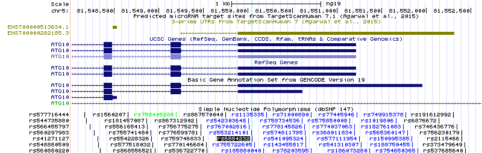

**Figure 2 |** ATG10 locus showing rs6884232 within it’s genomic context.

**STEP 13.** Next, we will extract the UTR sequences coordinates (hg19) from TargetScan in order to compare them to the SNP coordinates obtained in STEP 10. The sequence coordinates are in the *TSHuman_7_hg19_3UTRs.gff* file and we will once again use the `grep.file` function to search for the transcript IDs and use `merge` to add the respective coordinates to the UTR_sequences_hsa dataframe.

```r
transcript_id <- unique(UTR_sequences_hsa$Ensembl.ID)

UTR_coordinates_hg19_list <- lapply(transcript_id,grep.file, filename = "TSHuman_7_hg19_3UTRs.gff")
UTR_coordinates_hg19 <- do.call(rbind,UTR_coordinates_hg19_list)

coordinates_hg19_UTR_sequences_hsa <- merge(UTR_sequences_hsa, UTR_coordinates_hg19, by.x = "Ensembl.ID", by.y = "V9")
```

ATG10 has two available transcript sequences which will be `grep`ed. Notice that there may be more than one coordinate annotation for the same transcript ID. The actual sequence (In *UTR_Sequences.txt*) is the combination of all the respective coordinate annotations. Don’t worry as we will get back to this later (See Step 15).

```
## [1] "grep -P \"\\bENST00000282185.3\\b\" /home/acjfernandes/SNP_analysis_TargetScan_miRNA/R_Markdown/TSHuman_7_hg19_3UTRs.gff"
## [1] "grep -P \"\\bENST00000355178.4\\b\" /home/acjfernandes/SNP_analysis_TargetScan_miRNA/R_Markdown/TSHuman_7_hg19_3UTRs.gff"
```

**Table 6. |** `coordinates_hg19_UTR_sequences_hsa` for rs6884232. Fift collumn ‘UTR.sequence’ is ommited.

| Ensembl.ID | Gene.ID | Gene.Symbol | Species.ID | V1 | V2 | V3 | V4 | V5 | V6 | V7 | V8 |
| --- | --- | --- | --- | --- | --- | --- | --- | --- | --- | --- | --- |
| ENST00000282185.3 | ENSG00000152348.11 | ATG10 | 9606 | chr5 | TS7 | UTR | 81549245 | 81549248 | 3 | + | . |
| ENST00000282185.3 | ENSG00000152348.11 | ATG10 | 9606 | chr5 | TS7 | UTR | 81549887 | 81552311 | 2424 | + | . |
| ENST00000355178.4 | ENSG00000152348.11 | ATG10 | 9606 | chr5 | TS7 | UTR | 81443171 | 81443936 | 765 | + | . |

### 6. Build dataset

**STEP 14.** Now that we have both the UTR sequence coordinates and the SNP coordinates, it’s time to merge these information’s.

```r
snp_hgnc.symbol <- unique(BioRelevant_miRNAarm_3UTR[,c("refsnp_id","hgnc_symbol")])

snp_range <- merge(snp_coordinates_hg19,snp_hgnc.symbol, by.x = "refsnp_id", by.y = "refsnp_id")
snp_range<- merge(snp_range,coordinates_hg19_UTR_sequences_hsa, by.x = "hgnc_symbol", by.y = "Gene.Symbol")
```

```
## [1] WARNING: 1 out of 1 have an available gene sequence
```

**Table 7. |** `snp_range` for rs6884232. Eleventh collumn ‘UTR.sequence’ is ommited on purpose.

| hgnc_symbol | refsnp_id | chr_name | chrom_start | allele | allele_1 | minor_allele | Ensembl.ID | Gene.ID | Species.ID | V1 | V2 | V3 | V4 | V5 | V6 | V7 | V8 |
| --- | --- | --- | --- | --- | --- | --- | --- | --- | --- | --- | --- | --- | --- | --- | --- | --- | --- |
| ATG10 | rs6884232 | 5 | 81550043 | G/A | A | G | ENST00000282185.3 | ENSG00000152348.11 | 9606 | chr5 | TS7 | UTR | 81549245 | 81549248 | 3 | + | . |
| ATG10 | rs6884232 | 5 | 81550043 | G/A | A | G | ENST00000282185.3 | ENSG00000152348.11 | 9606 | chr5 | TS7 | UTR | 81549887 | 81552311 | 2424 | + | . |
| ATG10 | rs6884232 | 5 | 81550043 | G/A | A | G | ENST00000355178.4 | ENSG00000152348.11 | 9606 | chr5 | TS7 | UTR | 81443171 | 81443936 | 765 | + | . |

**STEP 15.** Next, `get.snp.position` will 1) check if the snp is inside the coordinates of it’s respective transcript(s) and 2) remove all snps that do not fall within those coordinate ranges, 3) check if the coordinate ranges for each transcript are continuous, i.e., there are no gaps, and if there are, take that into account when finding the snp position within the transcript, and 4) find the snp position within the transcript sequence (based on transcript strand).

In order to check if there are any gaps, `get.snp.position` calls `check.interval`.

```r
snp_in_range <- get.snp.position(range_info = snp_range)
```

```
## [1] There is a -638 gap in the provided intervals
```

For instance, take another look at table 6. If you try to order all the chromossomic coordinates for ATG10 transcript ENST00000282185.3, like this: **81549245:81549248 > 81549887:81552311**, you can clearly see that there is a discrepancy of 638 nucleotides. This means that you have to take this into account when finding the snp position within the transcript sequence, since the transcript is the combination of the nucleotides within these coordinates and you also have a chromossomic coordinate for the snp.

**Table 8. |** `snp_in_range` for rs6884232. Eleventh collumn ‘UTR.sequence’ is ommited on purpose.

| Ensembl.ID | hgnc_symbol | refsnp_id | chr_name | chrom_start | allele | allele_1 | minor_allele | Gene.ID | Species.ID | V1 | V2 | V3 | V4 | V5 | V6 | V7 | V8 | ranges | Seq_start | Seq_end | position_in_sequence | gap |
| --- | --- | --- | --- | --- | --- | --- | --- | --- | --- | --- | --- | --- | --- | --- | --- | --- | --- | --- | --- | --- | --- | --- |
| ENST00000282185.3 | ATG10 | rs6884232 | 5 | 81550043 | G/A | A | G | ENSG00000152348.11 | 9606 | chr5 | TS7 | UTR | 81549887 | 81552311 | 2424 | + | . | TRUE | 81549245 | 81552311 | 161 | -638 |

**STEP 16.** Now that you have found the snp position within the available transcripts, you are only missing the information of how the alleles are transcribed in RNA. This obviously depends on the transcript strand. `allele.in.RNA.strand` first creates 4 columns (maximum number of alternative alleles) and fills those columns based on the `allele` column. Next, the nucleotides contained in those 4 columns are transcribed based on chromosome strand (`V7`).

```r
split_rows_in_range<- split(snp_in_range, rownames(snp_in_range))
snp_data<- lapply(split_rows_in_range, allele.in.RNA.strand)  # Get alleles in RNA
snp_data<- do.call("rbind",snp_data)
rownames(snp_data)<-c()
```

| Ensembl.ID | hgnc_symbol | refsnp_id | chr_name | chrom_start | allele | allele_1 | minor_allele | Gene.ID | Species.ID | V1 | V2 | V3 | V4 | V5 | V6 | V7 | V8 | ranges | Seq_start | Seq_end | position_in_sequence | gap | nr_alleles | Allele_A | Allele_B | Allele_C | Allele_D |
| --- | --- | --- | --- | --- | --- | --- | --- | --- | --- | --- | --- | --- | --- | --- | --- | --- | --- | --- | --- | --- | --- | --- | --- | --- | --- | --- | --- |
| ENST00000282185.3 | ATG10 | rs6884232 | 5 | 81550043 | G/A | A | G | ENSG00000152348.11 | 9606 | chr5 | TS7 | UTR | 81549887 | 81552311 | 2424 | + | . | TRUE | 81549245 | 81552311 | 161 | -638 | 2 | G | A | NA | NA |

**STEP 17.** Now that you have all the necessary information (snp position and variant alleles in RNA), it’s time to replace the variant allele(s) for the reference allele in the available sequence. `replace.allele` will create a new row for each variant allele, which will differ in the `UTR.sequence` column by one RNA nucleotide. You can check which nucleotide that is by the `allele_in_sequence` column.

```r
split_rows_snp_data<- split(snp_data, rownames(snp_data))
split_rows_snp_data<- lapply(split_rows_snp_data, droplevels)

snp_expanded<- lapply(split_rows_snp_data, replace.allele)   # Replace allele in sequence
```

```
## [1] Done: rs6884232 for ref allele G in ATG10/ENST00000282185.3
```

```r
snp_in_seq<- do.call("rbind",snp_expanded)
rownames(snp_in_seq)<- c()
```

**Table 10. |** `snp_in_seq` for rs6884232. Eleventh collumn ‘UTR.sequence’ is ommited on purpose.

| Ensembl.ID | hgnc_symbol | refsnp_id | chr_name | chrom_start | allele | allele_1 | minor_allele | Gene.ID | Species.ID | V1 | V2 | V3 | V4 | V5 | V6 | V7 | V8 | ranges | Seq_start | Seq_end | position_in_sequence | gap | nr_alleles | Allele_A | Allele_B | Allele_C | Allele_D | allele_in_sequence |
| --- | --- | --- | --- | --- | --- | --- | --- | --- | --- | --- | --- | --- | --- | --- | --- | --- | --- | --- | --- | --- | --- | --- | --- | --- | --- | --- | --- | --- |
| ENST00000282185.3 | ATG10 | rs6884232 | 5 | 81550043 | G/A | A | G | ENSG00000152348.11 | 9606 | chr5 | TS7 | UTR | 81549887 | 81552311 | 2424 | + | . | TRUE | 81549245 | 81552311 | 161 | -638 | 2 | G | A | NA | NA | G |
| ENST00000282185.3 | ATG10 | rs6884232 | 5 | 81550043 | G/A | A | G | ENSG00000152348.11 | 9606 | chr5 | TS7 | UTR | 81549887 | 81552311 | 2424 | + | . | TRUE | 81549245 | 81552311 | 161 | -638 | 2 | G | A | NA | NA | A |

**STEP 18.** Finally, a tab-separated .txt file will be generated containing this information.

```r
write.table(snp_in_seq, paste0(working_path,"/TS_input_snp_data_", Sys.Date(),".txt"), sep = "\t", row.names = FALSE, quote = FALSE)
```

### 7. TargetScan command line

The application of TargetScan will be based on the run of several bash commands in order to run the Perl codes from R. In order to do that, a command line was build based on an unique identifier (**Pattern**) for each snp allele in a specific 3’UTR sequence.

**STEP 19.** So first, that unique identifier will be created based on hgnc_symbol::Ensembl.ID::refsnp_id::allele_in_sequence.

```r
snps_info_df <- snp_in_seq[,c("hgnc_symbol","Ensembl.ID","refsnp_id","allele_in_sequence")]

snp_in_seq$Pattern <- do.call("paste", c(snps_info_df, sep = "_"))
```

**Table 11. |** `snp_in_seq` for rs6884232. Eleventh collumn ‘UTR.sequence’ is ommited on purpose.

| Ensembl.ID | hgnc_symbol | refsnp_id | chr_name | chrom_start | allele | allele_1 | minor_allele | Gene.ID | Species.ID | V1 | V2 | V3 | V4 | V5 | V6 | V7 | V8 | ranges | Seq_start | Seq_end | position_in_sequence | gap | nr_alleles | Allele_A | Allele_B | Allele_C | Allele_D | allele_in_sequence | Pattern |
| --- | --- | --- | --- | --- | --- | --- | --- | --- | --- | --- | --- | --- | --- | --- | --- | --- | --- | --- | --- | --- | --- | --- | --- | --- | --- | --- | --- | --- | --- |
| ENST00000282185.3 | ATG10 | rs6884232 | 5 | 81550043 | G/A | A | G | ENSG00000152348.11 | 9606 | chr5 | TS7 | UTR | 81549887 | 81552311 | 2424 | + | . | TRUE | 81549245 | 81552311 | 161 | -638 | 2 | G | A | NA | NA | G | ATG10_ENST00000282185.3_rs6884232_G |
| ENST00000282185.3 | ATG10 | rs6884232 | 5 | 81550043 | G/A | A | G | ENSG00000152348.11 | 9606 | chr5 | TS7 | UTR | 81549887 | 81552311 | 2424 | + | . | TRUE | 81549245 | 81552311 | 161 | -638 | 2 | G | A | NA | NA | A | ATG10_ENST00000282185.3_rs6884232_A |

Also, a criterion will be made as a grouping pattern for each snp in a specific transcript.

```r
criterion<- unique(apply(snps_info_df[, 1:3], 1, paste0, collapse = "_"))
names(criterion) <- criterion
```

```
##   ATG10_ENST00000282185.3_rs6884232
## "ATG10_ENST00000282185.3_rs6884232"
```

**STEP 20.** Second, the command line will be generated based on that pattern. A variable named command.line will be added to your GlobalEnv.

```r
get.command.line.TS(snps_info_df)
```

**STEP 21.** Next a tab-separated .txt file will be generated for each row in snp_in_seq containing the Pattern, Species ID and the 3’UTR sequence.

```r
for (i in row(snp_in_seq))
  write.table(snp_in_seq[i,c("Pattern","Species.ID","UTR.sequence")],file = paste0(working_path,"/",(paste(snp_in_seq$hgnc_symbol[i], snp_in_seq$Ensembl.ID[i], snp_in_seq$refsnp_id[i], "allele", snp_in_seq$allele_in_sequence[i], sep = "_")),"_hsa.txt"),sep = "\t", quote = FALSE, row.names = FALSE, col.names = FALSE)
```

### 8. TargetScan Application

As mentioned above, TS is made of three steps, which actually involve the application of five distinct Perl scripts. Because we have generated all the commands in an uniform way and they are compiled in a dataframe, we can simply call in loop the `system` command function to execute those Perl scripts in bash without exiting the R IDE.

#### 8.1. Pilot Analysis: Human subset

A pilot analysis for human miRNAs and mRNAs is performed at the beginning with two main goals:

1. Enabling target prediction without context++ score calculation which require the Perl modules and RNAplfold application (See Dependencies.);
2. Provide a more efficient way of removing the background noise when the context++ score differences are acquired. This will be further explained later on.

**STEP 22.** First, a subset for human miRNA is made.

```r
if (dir.exists("./miR_Family_Info_hsa.txt") == FALSE){
  miR_Family_Info = read.table("./miR_Family_Info.txt", sep = "\t", header = TRUE)   # Subset miR file for human miR
  miR_Family_Info_hsa = miR_Family_Info[grep("^9606$", miR_Family_Info$Species.ID ),]
  write.table(miR_Family_Info_hsa, "./miR_Family_Info_hsa.txt",sep = "\t", quote = FALSE, row.names = FALSE)
}
```

**STEP 23.** Second, the first Perl code of TargetScan is executed based on the command generated at `command.line`.

Notice that the argument `wait` is TRUE. Since we are executing a bash command, the argument `wait` indicates whether the R interpreter should wait for the command to finish, or run it asynchronously. By switching it to FALSE, parallelization can be achieved. However you cannot move forward in the script until these processes have finished since their output will be needed, i.e., these code blocks have to be manually runned one by one.

```r
for (i in command.line$command_hsa)   # Execute targetscan_70.pl only with human miRNAs
  system(command = i, wait = TRUE)
```

**STEP 24.** Third, the results are read and grouped by the criterion, the differences between each file group are obtained by creating a .txt file started by ‘diff’ followed by the criterion name, and that file is read. Useful information such as the `chr_name`, `allele`, `snp_id`, `hgnc_symbol` and `transcript_id` are added based on the dataframe snp_data.

```r
targetscan_hsa_output <- lapply(criterion, read.file, suffix = "hsa_output")

for (i in targetscan_hsa_output)
  fun.diff(i, snp_data = snp_data)

targetscan_hsa_output_diff <- lapply(criterion, read.file.diff, header = "diff_")
```

**Table 13. |** `targetscan_hsa_output_diff` for rs6884232.

| miRNA_family_ID | species_ID | MSA_start | MSA_end | UTR_start | UTR_end | Site_type | allele | snp_id | hgnc_symbol | transcript_id | chr_name | alleles | allele_1 | minor_allele | position_in_sequence | chr_strand |
| --- | --- | --- | --- | --- | --- | --- | --- | --- | --- | --- | --- | --- | --- | --- | --- | --- |
| miR-499a-3p/499b-3p | 9606 | 327 | 332 | 159 | 164 | 6mer | A | rs6884232 | ATG10 | ENST00000282185.3 | 5 | G/A | A | G | 161 | + |
| miR-5094 | 9606 | 318 | 330 | 157 | 162 | 6mer | A | rs6884232 | ATG10 | ENST00000282185.3 | 5 | G/A | A | G | 161 | + |
| miR-1226-3p | 9606 | 319 | 331 | 158 | 163 | 6mer | G | rs6884232 | ATG10 | ENST00000282185.3 | 5 | G/A | A | G | 161 | + |
| miR-21-3p/3591-3p | 9606 | 327 | 333 | 159 | 165 | 7mer-m8 | G | rs6884232 | ATG10 | ENST00000282185.3 | 5 | G/A | A | G | 161 | + |
| miR-4733-3p | 9606 | 319 | 331 | 158 | 163 | 6mer | G | rs6884232 | ATG10 | ENST00000282185.3 | 5 | G/A | A | G | 161 | + |

#### 8.2. Analysis: 84-vertebrate species

**STEP 25.** Step 21 is repeated, this time with the addition of the respective 3’UTR sequences for the 83 vertebrate species. These do not suffer any modification, unlike the human sequence (which may have an alternative allele).

```r
UTR_sequences_species<- UTR_sequences[grep("^9606$",UTR_sequences$Species.ID, invert = TRUE),]  # Human species = 9606

for (i in row(snp_in_seq)) {
  y<- snp_in_seq[i, c("Ensembl.ID","Gene.ID","hgnc_symbol","Species.ID","UTR.sequence")]
  colnames(y)[3]<- "Gene.Symbol"
  ensembl<- snp_in_seq[i, "Ensembl.ID"]
  g<- rbind(y, UTR_sequences_species)
  z<- g[grep(ensembl, g$Ensembl.ID),]
  pat<- snp_in_seq[i,"Pattern"]
  z<- cbind(z,pat)
  write.table(z[,c(6,4,5)], paste0(working_path,"/",paste(snp_in_seq$hgnc_symbol[i],snp_in_seq$Ensembl.ID[i],snp_in_seq$refsnp_id[i], "allele",snp_in_seq$allele_in_sequence[i],"species", sep = "_"), ".txt"), sep = "\t", row.names = FALSE, col.names = FALSE, quote = FALSE )
}
```

**STEP 26.** Step 23 is repeated using `command_1`.

```r
for (i in command.line$command_1)    # Execute targetscan_70.pl
  system(command = i, wait = TRUE)
```

**STEP 27.** The second Perl code set is executed to calculate probability of preferentially conserved targeting (PCT).

```r
for (i in command.line$command_2)    # Execute targetscan_70_BL_bins.pl
    system(command = i, wait = TRUE)

for (i in command.line$command_3)    # Execute targetscan_70_BL_PCT.pl
  system(command = i, wait = TRUE)
```

**STEP 28.** Before the execution of the fifth and final Perl code to calculate context++ scores, 8mer counts in ORFs must be calculated. Fist we have to subset our respective transcripts from the ORF dataset and create independent .txt files according to TargetScan instructions and only then execute the Perl code.

```r
transcripts_gene <-unique(snp_in_seq[,c("Ensembl.ID","hgnc_symbol","Pattern")])
transcripts <- as.list(droplevels(unique(transcripts_gene$Ensembl.ID)))

ORF_sequences_hg19_list <-lapply(transcripts,grep.file, filename = "ORF_Sequences.txt")
ORF_sequences_hg19 <- do.call(rbind, ORF_sequences_hg19_list)
ORF_sequences_hg19 <- merge(ORF_sequences_hg19, transcripts_gene, by.x = "V1", by.y = "Ensembl.ID")

ORF_split <- split(ORF_sequences_hg19, ORF_sequences_hg19$V1)

for (i in names(ORF_split)){
  x<- ORF_split[[i]]
  y<-x[,c("Pattern","V2","V3")]
  write.table(y, paste0(working_path,"/",paste("ORF",x$hgnc_symbol[1],i, sep = "_"), ".txt"), sep = "\t", quote = FALSE, row.names = FALSE, col.names = FALSE)
}

for (i in unique(command.line$command_4))    # Execute targetscan_count_8mers.pl
  system(command = i, wait = TRUE)
```

**STEP 29.** In order to run the last Perl code (*targetscan_70_context_scores.pl*), two existing files must be further processed according to instructions.

1. *miR_Family_Info_hsa.txt* must be subsetted for particular columns.

```r
# Resize dataframe for context score application (command 5)
if (dir.exists("./miR_hsa_for_context_scores.txt") == FALSE){
  system(command = "cut -f1,3,4,5 ./miR_Family_Info_hsa.txt > ./miR_hsa_for_context_scores.txt", intern = TRUE, wait = TRUE)
  }
```

2. *All_cell_lines.AIRs.txt* needs some modifications.

Alternative polyadenilation can affect the inclusion of regulatory sites in the 3’UTR and therefore, the existence of alternative 3’UTRs can lead to differential repression of mRNAs. The parameter AIR indicates the fraction of mRNA transcripts containing a certain miRNA target site based 3P-seq data ([Nam et al 2014](http://www.sciencedirect.com/science/article/pii/S1097276514001294)) for the cell lines HEK293, HeLa, Huh7 and IMR90.

Because we have been using the `Pattern` as the ID for each unique gene::transcript::snp::allele combination (In the example: ATG10_ENST00000282185.3_rs6884232_G and ATG10_ENST00000282185.3_rs6884232_A) instead of the transcript ID (used by TargetScan; in this case: ENST00000282185.3), when the final .pl code looks at the *All_cell_lines.AIRs.txt* it will not find any correspondent. Therefore, the corresponding AIR for each transcript must be find and the ID changed to match the `Pattern`. Alternatively, usage of this parameter can be set to 0 (`get.AIRs(0)`) and therefore not taken into consideration when calculating the context++score (it will be set to 1, meaning the transcript is the only existent isoform). Keep in mind that the latter will influence calculation of the parameters `len_3UTR` and `min_dist`.

```r
# Rename ID in All_cell_lines.AIRs.txt to match 'Pattern', otherwise the script will not recognize them
# 'All_cell_lines.AIRs.txt' file name is hardcoded in the targetscan_70_context_scores.pl script
get.AIRs(1)  # range 0:1 || 1: Subset AIR file for used transcripts id and replace by 'Pattern' in new AIR file  | 0: Use the original AIR dataset
```

**STEP 30.** Finally we can execute the last Perl code and calculate the context++ scores.

```r
for (i in command.line$command_5)    # Execute targetscan_70_context_scores.pl
  system(command = i, wait = TRUE)
```

**STEP 31.** Step 24 is repeated.

```r
targetscan_output_cs_df <- lapply(criterion, read_ts_cs_outputs, suffix = "output_context_score.txt")


#Run differences for each one
for (i in targetscan_output_cs_df)
  fun.diff.cs(i, snp_data = snp_data)


targetscan_output_cs_diff <- lapply(criterion, read.file.diff, header = "diff_cs_")
```

**Table 14. |** `targetscan_output_cs_diff` for rs6884232.

| Species.ID | Mirbase.ID | Site.Type | UTR.start | UTR.end | context…score | miRNA.family | allele | snp_id | hgnc_symbol | transcript_id | chr_name | alleles | allele_1 | minor_allele | position_in_sequence | chr_strand |
| --- | --- | --- | --- | --- | --- | --- | --- | --- | --- | --- | --- | --- | --- | --- | --- | --- |
| 9606 | hsa-miR-1254 | 7mer-1a | 214 | 220 | -0.207 | miR-1254/3116 | A | rs6884232 | ATG10 | ENST00000282185.3 | 5 | G/A | A | G | 161 | + |
| 9606 | hsa-miR-3116 | 7mer-1a | 214 | 220 | -0.206 | miR-1254/3116 | A | rs6884232 | ATG10 | ENST00000282185.3 | 5 | G/A | A | G | 161 | + |
| 9606 | hsa-miR-1537-5p | 7mer-1a | 150 | 156 | -0.169 | miR-1537-5p | A | rs6884232 | ATG10 | ENST00000282185.3 | 5 | G/A | A | G | 161 | + |
| 9606 | hsa-miR-181a-5p | 7mer-m8 | 174 | 180 | -0.095 | miR-181-5p | A | rs6884232 | ATG10 | ENST00000282185.3 | 5 | G/A | A | G | 161 | + |
| 9606 | hsa-miR-181b-5p | 7mer-m8 | 174 | 180 | -0.095 | miR-181-5p | A | rs6884232 | ATG10 | ENST00000282185.3 | 5 | G/A | A | G | 161 | + |
| 9606 | hsa-miR-181c-5p | 7mer-m8 | 174 | 180 | -0.095 | miR-181-5p | A | rs6884232 | ATG10 | ENST00000282185.3 | 5 | G/A | A | G | 161 | + |
| 9606 | hsa-miR-181d-5p | 7mer-m8 | 174 | 180 | -0.095 | miR-181-5p | A | rs6884232 | ATG10 | ENST00000282185.3 | 5 | G/A | A | G | 161 | + |
| 9606 | hsa-miR-4262 | 7mer-m8 | 174 | 180 | -0.043 | miR-181-5p | A | rs6884232 | ATG10 | ENST00000282185.3 | 5 | G/A | A | G | 161 | + |
| 9606 | hsa-miR-188-5p | 8mer-1a | 198 | 205 | -0.437 | miR-188-5p | A | rs6884232 | ATG10 | ENST00000282185.3 | 5 | G/A | A | G | 161 | + |
| 9606 | hsa-miR-6866-3p | 8mer-1a | 198 | 205 | -0.356 | miR-188-5p | A | rs6884232 | ATG10 | ENST00000282185.3 | 5 | G/A | A | G | 161 | + |
| 9606 | hsa-miR-204-5p | 7mer-m8 | 197 | 203 | -0.140 | miR-204-5p/211-5p | A | rs6884232 | ATG10 | ENST00000282185.3 | 5 | G/A | A | G | 161 | + |
| 9606 | hsa-miR-211-5p | 7mer-m8 | 197 | 203 | -0.162 | miR-204-5p/211-5p | A | rs6884232 | ATG10 | ENST00000282185.3 | 5 | G/A | A | G | 161 | + |
| 9606 | hsa-miR-20b-3p | 6mer | 149 | 154 | -0.051 | miR-20b-3p | A | rs6884232 | ATG10 | ENST00000282185.3 | 5 | G/A | A | G | 161 | + |
| 9606 | hsa-miR-3121-5p | 6mer | 196 | 201 | -0.025 | miR-3121-5p | A | rs6884232 | ATG10 | ENST00000282185.3 | 5 | G/A | A | G | 161 | + |
| 9606 | hsa-miR-3137 | 6mer | 149 | 154 | -0.034 | miR-3137 | A | rs6884232 | ATG10 | ENST00000282185.3 | 5 | G/A | A | G | 161 | + |
| 9606 | hsa-miR-3148 | 7mer-m8 | 127 | 133 | -0.070 | miR-3148 | A | rs6884232 | ATG10 | ENST00000282185.3 | 5 | G/A | A | G | 161 | + |
| 9606 | hsa-miR-3157-5p | 7mer-1a | 171 | 177 | -0.236 | miR-3157-5p | A | rs6884232 | ATG10 | ENST00000282185.3 | 5 | G/A | A | G | 161 | + |
| 9606 | hsa-miR-3171 | 8mer-1a | 203 | 210 | -0.290 | miR-3171 | A | rs6884232 | ATG10 | ENST00000282185.3 | 5 | G/A | A | G | 161 | + |
| 9606 | hsa-miR-3190-5p | 7mer-m8 | 211 | 217 | -0.240 | miR-3190-5p | A | rs6884232 | ATG10 | ENST00000282185.3 | 5 | G/A | A | G | 161 | + |
| 9606 | hsa-miR-3657 | 7mer-1a | 137 | 143 | -0.148 | miR-3657 | A | rs6884232 | ATG10 | ENST00000282185.3 | 5 | G/A | A | G | 161 | + |
| 9606 | hsa-miR-3713 | 7mer-1a | 201 | 207 | -0.177 | miR-3713 | A | rs6884232 | ATG10 | ENST00000282185.3 | 5 | G/A | A | G | 161 | + |
| 9606 | hsa-miR-3912-5p | 6mer | 136 | 141 | -0.050 | miR-3912-5p | A | rs6884232 | ATG10 | ENST00000282185.3 | 5 | G/A | A | G | 161 | + |
| 9606 | hsa-miR-3927-5p | 7mer-m8 | 166 | 172 | -0.198 | miR-3927-5p | A | rs6884232 | ATG10 | ENST00000282185.3 | 5 | G/A | A | G | 161 | + |
| 9606 | hsa-miR-4255 | 6mer | 189 | 194 | -0.020 | miR-4255 | A | rs6884232 | ATG10 | ENST00000282185.3 | 5 | G/A | A | G | 161 | + |
| 9606 | hsa-miR-4263 | 6mer | 181 | 186 | -0.011 | miR-4263 | A | rs6884232 | ATG10 | ENST00000282185.3 | 5 | G/A | A | G | 161 | + |
| 9606 | hsa-miR-4475 | 6mer | 131 | 136 | -0.107 | miR-4475 | A | rs6884232 | ATG10 | ENST00000282185.3 | 5 | G/A | A | G | 161 | + |
| 9606 | hsa-miR-4659a-3p | 8mer-1a | 183 | 190 | -0.252 | miR-4659a-3p/4659b-3p | A | rs6884232 | ATG10 | ENST00000282185.3 | 5 | G/A | A | G | 161 | + |
| 9606 | hsa-miR-4659b-3p | 8mer-1a | 183 | 190 | -0.252 | miR-4659a-3p/4659b-3p | A | rs6884232 | ATG10 | ENST00000282185.3 | 5 | G/A | A | G | 161 | + |
| 9606 | hsa-miR-4668-5p | 7mer-m8 | 128 | 134 | -0.172 | miR-4668-5p | A | rs6884232 | ATG10 | ENST00000282185.3 | 5 | G/A | A | G | 161 | + |
| 9606 | hsa-miR-4669 | 7mer-1a | 137 | 143 | -0.252 | miR-4669 | A | rs6884232 | ATG10 | ENST00000282185.3 | 5 | G/A | A | G | 161 | + |

[output cut: 73 more lines]

### 9. Generating Plots

As you can see in Table 14, there are a lot more results than in Table 13. That is due to two things:

1. In table 13, it is only shown miRNA families (which can include more than one miRNA) and not the miRBase ID;
2. When the differences between each output file are checked, if there is any single different character, it will be assumed as a difference and shown in the *diff* file.

For instance, take a look at this **example from Table 14**:

- hsa-miR-1254 in allele A is also present in allele G. Therefore you would expect that they must have significant differences. However, their only difference is that the first has a context++ score of -207 and the second of -208.

**Table 15. |** Table 14 subset, showing line 1 and 53.

|  | Species.ID | Mirbase.ID | Site.Type | UTR.start | UTR.end | context…score | miRNA.family | allele | snp_id | hgnc_symbol | transcript_id | chr_name | alleles | allele_1 | minor_allele | position_in_sequence | chr_strand |
| --- | --- | --- | --- | --- | --- | --- | --- | --- | --- | --- | --- | --- | --- | --- | --- | --- | --- |
| 1 | 9606 | hsa-miR-1254 | 7mer-1a | 214 | 220 | -0.207 | miR-1254/3116 | A | rs6884232 | ATG10 | ENST00000282185.3 | 5 | G/A | A | G | 161 | + |
| 53 | 9606 | hsa-miR-1254 | 7mer-1a | 214 | 220 | -0.208 | miR-1254/3116 | G | rs6884232 | ATG10 | ENST00000282185.3 | 5 | G/A | A | G | 161 | + |

**STEP 32.** In order to remove this **background noise**, the results from targetscan_output_cs_diff (Table 14) are normalised by the results in targetscan_hsa_output_diff (Table 13), generating a new tab-separated .txt file (*diff_cs_norm*). The results are then read into your GlobalEnv.

```r
for (i in targetscan_output_cs_diff)
  fun.diff.cs.norm(i, output_hsa_diff = targetscan_hsa_output_diff)

targetscan_output_cs_diff_norm <- lapply(criterion, read.file.diff, header = "diff_cs_norm_")
```

**Table 16. |** `targetscan_output_cs_diff` normalised by `targetscan_hsa_output_diff`.

| Species.ID | Mirbase.ID | Site.Type | UTR.start | UTR.end | context…score | miRNA.family | allele | snp_id | hgnc_symbol | transcript_id | chr_name | alleles | allele_1 | minor_allele | position_in_sequence | chr_strand |
| --- | --- | --- | --- | --- | --- | --- | --- | --- | --- | --- | --- | --- | --- | --- | --- | --- |
| 9606 | hsa-miR-1226-3p | 6mer | 158 | 163 | -0.048 | miR-1226-3p | G | rs6884232 | ATG10 | ENST00000282185.3 | 5 | G/A | A | G | 161 | + |
| 9606 | hsa-miR-21-3p | 7mer-m8 | 159 | 165 | -0.169 | miR-21-3p/3591-3p | G | rs6884232 | ATG10 | ENST00000282185.3 | 5 | G/A | A | G | 161 | + |
| 9606 | hsa-miR-3591-3p | 7mer-m8 | 159 | 165 | -0.162 | miR-21-3p/3591-3p | G | rs6884232 | ATG10 | ENST00000282185.3 | 5 | G/A | A | G | 161 | + |
| 9606 | hsa-miR-4733-3p | 6mer | 158 | 163 | -0.046 | miR-4733-3p | G | rs6884232 | ATG10 | ENST00000282185.3 | 5 | G/A | A | G | 161 | + |
| 9606 | hsa-miR-499a-3p | 6mer | 159 | 164 | -0.039 | miR-499a-3p/499b-3p | A | rs6884232 | ATG10 | ENST00000282185.3 | 5 | G/A | A | G | 161 | + |
| 9606 | hsa-miR-499b-3p | 6mer | 159 | 164 | -0.039 | miR-499a-3p/499b-3p | A | rs6884232 | ATG10 | ENST00000282185.3 | 5 | G/A | A | G | 161 | + |
| 9606 | hsa-miR-5094 | 6mer | 157 | 162 | -0.022 | miR-5094 | A | rs6884232 | ATG10 | ENST00000282185.3 | 5 | G/A | A | G | 161 | + |

**STEP 33.** These results are also compiled into a single tab-separated .txt file (called *targetscan_results.txt*) by `compile.tables`. If you have chosen to subset your analysis by miRNA expressed in the available datasets (`get.miR.expression(1)` or `get.miR.expression(2)`), `compile.tables` will generate an additional file based on that subset (*targetscan_results_expressed_miRNA_Normal_Breast.txt* or *targetscan_results_expressed_miRNA_Cancer_Breast.txt*).

```r
compile.tables(targetscan_output_cs_diff_norm, miR_expression = miR_normalization)  # Make a table txt file compiling all normalized diff_cs. Also compiles miR normalization table for all.
```

**Table 17. |** Table subsetted by miRNA expressed in normal breast.

| Mirbase.ID | Species.ID | Site.Type | UTR.start | UTR.end | context…score | miRNA.family | allele | snp_id | hgnc_symbol | transcript_id | chr_name | alleles | allele_1 | minor_allele | position_in_sequence | chr_strand | miR_norm |
| --- | --- | --- | --- | --- | --- | --- | --- | --- | --- | --- | --- | --- | --- | --- | --- | --- | --- |
| hsa-miR-1226-3p | 9606 | 6mer | 158 | 163 | -0.048 | miR-1226-3p | G | rs6884232 | ATG10 | ENST00000282185.3 | 5 | G/A | A | G | 161 | + | miRmine_SRX513286_normal_breast |
| hsa-miR-21-3p | 9606 | 7mer-m8 | 159 | 165 | -0.169 | miR-21-3p/3591-3p | G | rs6884232 | ATG10 | ENST00000282185.3 | 5 | G/A | A | G | 161 | + | miRmine_SRX513286_normal_breast |
| hsa-miR-5094 | 9606 | 6mer | 157 | 162 | -0.022 | miR-5094 | A | rs6884232 | ATG10 | ENST00000282185.3 | 5 | G/A | A | G | 161 | + | miRmine_SRX513286_normal_breast |

#### 9.1 Plots

Now that your analysis is completed, it is time to extrapolate those results to a more visual output, in this case by making plots.

The generated plots are based in a two-colour heat-map scale (See Figure 3):

- The lower the context++ score, the redder the colour in the plot, whereas the higher the context++ score, the whiter the colour for a determined set of miRNA::allele.

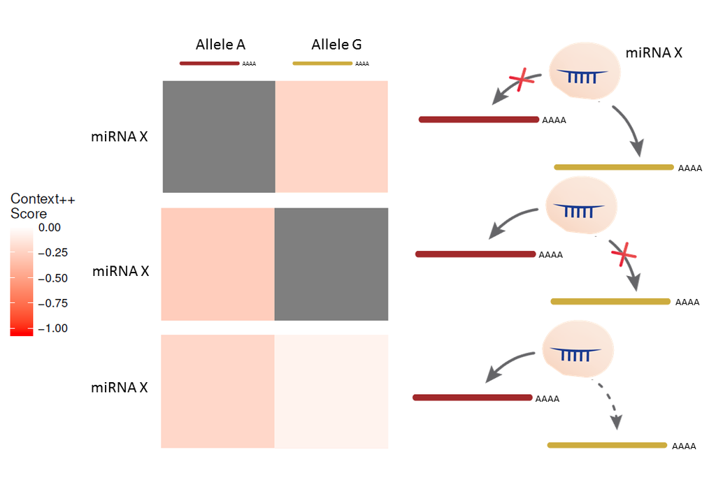

**Figure 3 |** Understanding the biological meaning of the plot. Per each combination of transcript::snp, a plot is generated showing miRNA (y-axis) predictded ligation per variant allele (x-axis). In the upper pannel, miRNA X is predicted to bind only sequences which have the G allele. Notice that grey blocks represents **no** predicted binding. The inverse situation, where miRNA X is predicted to only bind sequences which contain the A allele, is represented in the middle pannel. In the final pannel, miRNA X is predicted to bind both sequences (either A or G). However it is predicted that miRNA X would rather bind sequences which contain the A allele than sequences with the G allele.

```r
# Set scale for all
# Min
min_cs_by_diff.file <- lapply(targetscan_output_cs_df, get.min, by.c = "context...score")

min_cs<- unlist(min_cs_by_diff.file)
names(min_cs) <- c()

min_cs<- min(min_cs)  # Minimum context++ score for the provided dataset


# Max
max_cs_by_diff.file <- lapply(targetscan_output_cs_df, get.max, by.c = "context...score")

max_cs<- unlist(max_cs_by_diff.file)
names(max_cs) <- c()

max_cs<- max(max_cs)  # Maximum context++ score for the provided dataset

cs_range <- c(min_cs,max_cs)  # vector of max,min context++ scores in dataset
```

**STEP 35.** Finally, we can generate the plots using [ggplot2](https://cran.r-project.org/web/packages/ggplot2/index.html). `fun.diff.cs.plot` creates one folder named *Plots_cs_diff* and a sub-folder called *Expressed* in your working_path and generates one plot per transcript::snp combination (criterion), which will be stored in the folder *Plots_cs_diff*. These plots are automatically stored in two formats: .png and .pdf , both with A4 dimentions. Depending on miR_normalization (if 1 or 2), plots containing the miRNA subset will be generated in the sub-folder *Expressed*.

```r
for (i in targetscan_output_cs_diff_norm)
  fun.diff.cs.plot(i, miR_expression = miR_normalization, scale_limit = cs_range)
```

**STEP 36.** Because we have generated .pdfs for each plot, we can merge them into one.

```r
# Merge plots.pdf into single pdf

Plots <- list.files(paste0(working_path,"/Plots_cs_diff"),pattern = ".pdf")
plotflow:::mergePDF(
  in.file = paste0(working_path,"/Plots_cs_diff/",Plots),
  file = paste0(working_path,"/Plots_cs_diff/Results_TS7_CS.pdf"))

Plots_Expressed <- list.files(paste0(working_path,"/Plots_cs_diff/Expressed"),pattern = ".pdf")
plotflow:::mergePDF(
  in.file = paste0(working_path,"/Plots_cs_diff/Expressed/",Plots_Expressed),
  file = paste0(working_path,"/Plots_cs_diff/Expressed/Results_TS7_CS_Expressed.pdf"))
```

### 10. Save data and Session Info

**STEP 37.** The last Perl code will create a folder named *RNAplfold_in_out* in your directory where it will store the data generated from the RNAplfold Application (if installed). Because we have used an unique identifier (**Pattern**) for our analysis, these files will also be generated with that name. Each time, *targetscan_70_context_scores.pl* is runned, it checks for this folder and if there is any file containing a matching identifier, it will use those results so that it doesn’t have to run the application again. You can choose to run the application every single time you perform the analysis but still store the previous results by assigning that folder to your working_path (default) or eliminate this step if you want to use those results recursively. Also, you should allocate *All_cell_lines.AIRs.txt* to your working_path folder if you have used `get.AIR(1)`.

```r
file.rename(paste0(getwd(),"/RNAplfold_in_out"),paste0(working_path,"/RNAplfold_in_out")) # Remove this if you want to use these results recursively
file.rename(from = paste0(getwd(),"/All_cell_lines.AIRs.txt"), to = paste0(working_path,"/All_cell_lines.AIRs.sample.txt"))  # Relocate file with subset of AIR used in this analysis
```

**STEP 38.** Save your GlobalEnv and History. Print your `sessionInfo()`.

```r
save.image(file = paste0(working_path,"/.RData"))  # Save environment
savehistory(file = paste0(working_path,"/.Rhistory"))  # Save history

sessionInfo()
# R version 3.3.2 (2016-10-31)
# Platform: x86_64-pc-linux-gnu (64-bit)
# Running under: Ubuntu 16.04.1 LTS

# [1] plotflow_0.1.0  devtools_1.12.0 reshape2_1.4.2  ggplot2_2.2.1   biomaRt_2.30.0
```